# MATH1115 Computer Practical Exam (SAMPLE EXAM + ANSWERS)

Semester 1 2019

*Note: below is a sample exam.*

It is based on the `msleep` dataset, which is provided with ggplot2. It contains information about sleep and awake times of different mammals. Below is given some suggested code in the code blocks. In your exam, the code blocks will be mostly blank, with some occasional hints provided.

## MY SID IS: XXXXX

## 0.1 INITIAL DATA ANALYSIS

Load packages and data

```r
library(tidyverse)
library(ggthemes)
library(ggplot2)
sleep = msleep
```

**Question1**: Conduct an initial data analysis to determine the structure of your data. Write a concise summary,

```r
# Add your code below

help(msleep)
str(sleep)
```

```
## Classes 'tbl_df', 'tbl' and 'data.frame':    83 obs. of  11 variables:
##  $ name        : chr  "Cheetah" "Owl monkey" "Mountain beaver" "Greater short-tailed shrew" ...
##  $ genus       : chr  "Acinonyx" "Aotus" "Aplodontia" "Blarina" ...
##  $ vore        : chr  "carni" "omni" "herbi" "omni" ...
##  $ order       : chr  "Carnivora" "Primates" "Rodentia" "Soricomorpha" ...
##  $ conservation: chr  "lc" NA "nt" "lc" ...
##  $ sleep_total : num  12.1 17 14.4 14.9 4 14.4 8.7 7 10.1 3 ...
##  $ sleep_rem   : num  NA 1.8 2.4 2.3 0.7 2.2 1.4 NA 2.9 NA ...
##  $ sleep_cycle : num  NA NA NA 0.133 0.667 ...
##  $ awake       : num  11.9 7 9.6 9.1 20 9.6 15.3 17 13.9 21 ...
##  $ brainwt     : num  NA 0.0155 NA 0.00029 0.423 NA NA NA 0.07 0.0982 ...
##  $ bodywt      : num  50 0.48 1.35 0.019 600 ...
```

The data set contains 83 mammals, with 11 variables, representing the classification of mammal (name, genus, vore, order), conservation status, sleep patterns (total, rem, cycle, awake), and brain and body weight.

**Question2**: Across all the mammals, what is the average body weight? How does this compare to the median? Explain your findings.

```r
# Add your code

mean(sleep$bodywt)
```

```
## [1] 166.1363
```

```r
median(sleep$bodywt)
```

```
## [1] 1.67
```

```r
# Investigate further
summary(sleep$bodywt)
```

```
##     Min.  1st Qu.   Median     Mean  3rd Qu.     Max.
##    0.005    0.174    1.670  166.136   41.750 6654.000
```

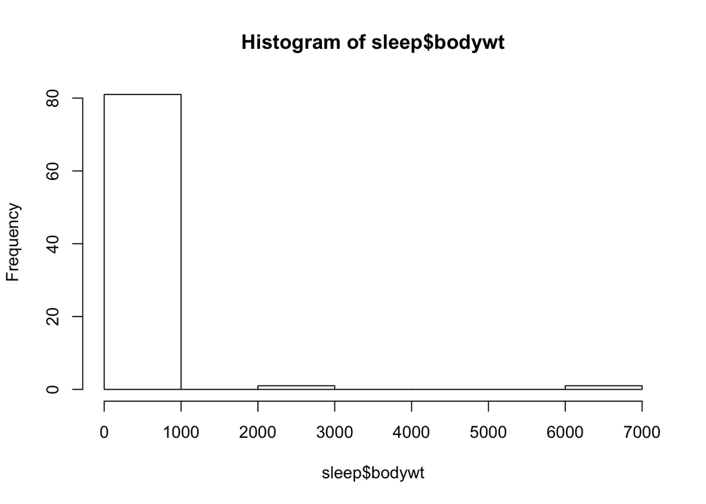

```r
hist(sleep$bodywt)
```

```r
sleep$name[sleep$bodywt == max(sleep$bodywt)]
```

```
## [1] "African elephant"
```

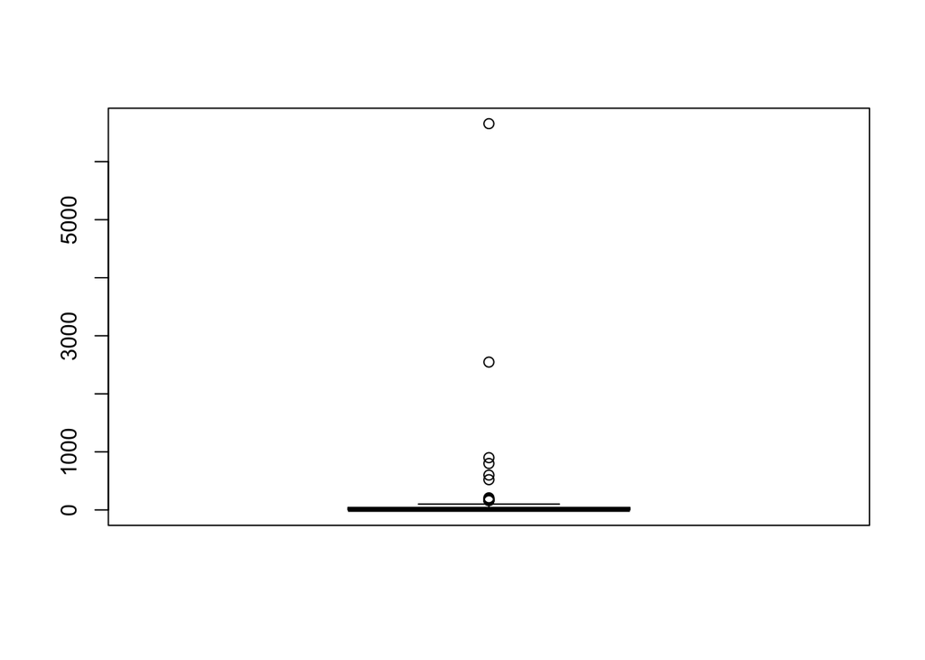

```r
boxplot(sleep$bodywt)
```

- The average body weight across all the mammals is 166.14 (presume unit is kg; 2 dp), compared to a tiny median of 1.67.
- A fuller summary shows a huge range of weights, so there are issues with robustness (hence using the mean would not be appropriate). The African elephant is the heaviest mammal, which is an outlier (along with other outliers).

**Question3**: Which mammal has the biggest brain weight? What is a limitation of this analysis? What is a research question arising from syntheising Q2 and Q3?

```r
# Add your code

summary(sleep$brainwt)
```

```
##    Min. 1st Qu.  Median    Mean 3rd Qu.    Max.    NA's
## 0.00014 0.00290 0.01240 0.28158 0.12550 5.71200      27
```

```r
27/length(sleep$brainwt)
```

```
## [1] 0.3253012
```

```r
max(sleep$brainwt, na.rm=T)
```

```
## [1] 5.712
```

```r
sleep$name[sleep$brainwt == max(sleep$brainwt, na.rm=T)]
```

```
##  [1] NA                 NA                 NA
##  [4] NA                 NA                 NA
##  [7] NA                 NA                 NA
## [10] NA                 "African elephant" NA
## [13] NA                 NA                 NA
## [16] NA                 NA                 NA
## [19] NA                 NA                 NA
## [22] NA                 NA                 NA
## [25] NA                 NA                 NA
## [28] NA
```

**Question 4:** Describe the pattern of total sleep in mammals? Would a Normal model be appropriate?

```r
# Add your code

summary(sleep$sleep_total)
```

```
##    Min. 1st Qu.  Median    Mean 3rd Qu.    Max.
##    1.90    7.85   10.10   10.43   13.75   19.90
```

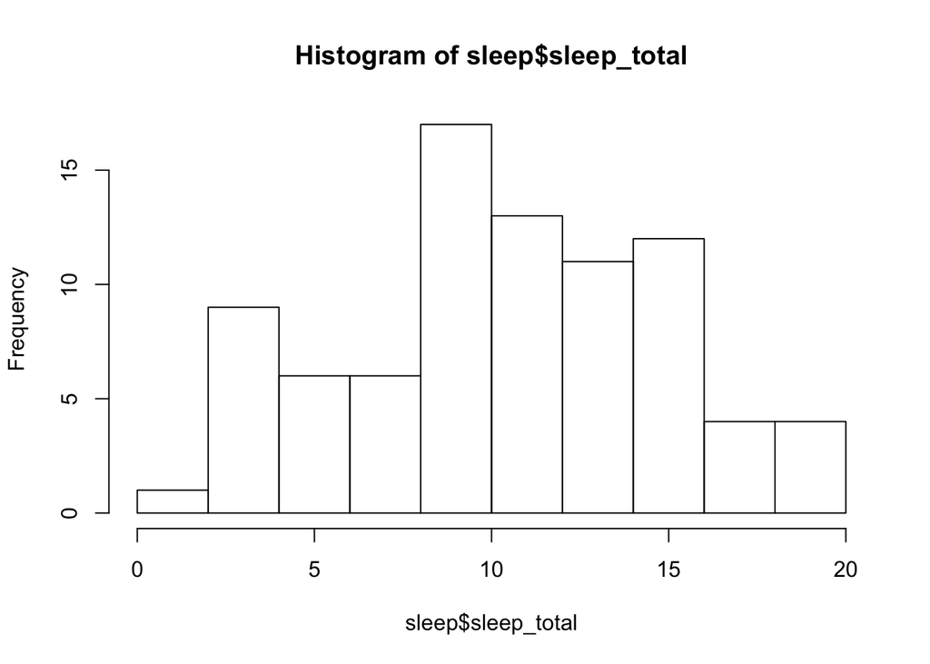

```r
hist(sleep$sleep_total)
```

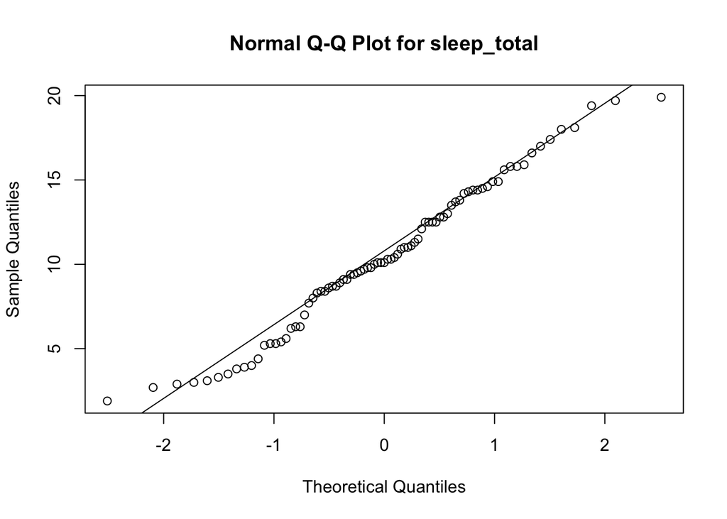

```r
qqnorm(sleep$sleep_total, main='Normal Q-Q Plot for sleep_total')
qqline(sleep$sleep_total)
```

- From this data, there isn a big variation in hours slept by the mammals. The average is around 10 hours, with minimum 2 hours and maximum 20 hours!
- The Normal curve appears to fit well.

**Question 4:** Describe the pattern of REM sleep in mammals? Would a Normal model be appropriate?

```r
# Add your code

summary(sleep$sleep_rem)
```

```
##    Min. 1st Qu.  Median    Mean 3rd Qu.    Max.    NA's
##   0.100   0.900   1.500   1.875   2.400   6.600      22
```

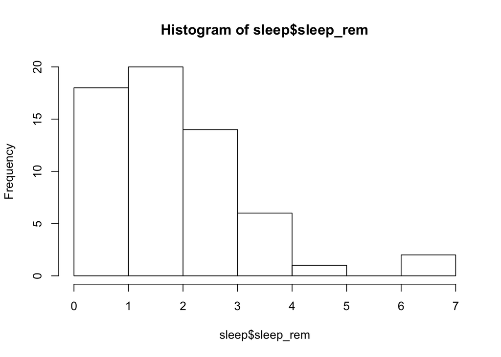

```r
hist(sleep$sleep_rem)
```

```r
sd(sleep$sleep_rem, na.rm=T)
```

```
## [1] 1.298288
```

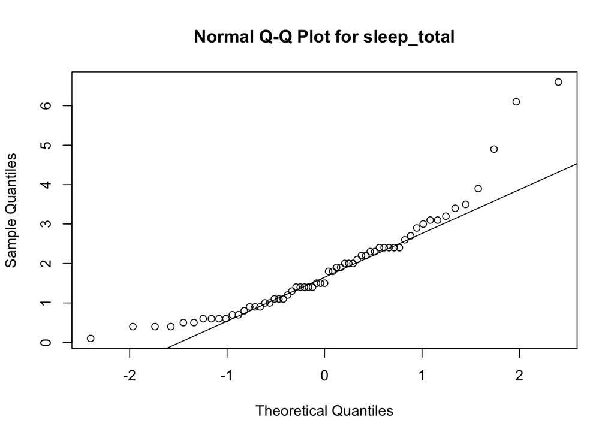

```r
qqnorm(sleep$sleep_rem, main='Normal Q-Q Plot for sleep_total')
qqline(sleep$sleep_rem)
```

- From this data, the amount of REM sleep is muhc more compact (compared to total sleep), with a right skewed distribution, with a mean around 2 and SD 1.
- The Normal curve does not fit well.

## 0.2 SIMPLE LINEAR REGRESSION

**Research Question**: Is there a linear relationship between brain weight and body weight for mammals? Explain the extra code given for residual plot.

```r
# Add code here

plot(sleep$bodywt, sleep$brainwt)
cor(sleep$bodywt, sleep$brainwt) # Note effect of missing values
```

```
## [1] NA
```

```r
cor(sleep$bodywt, sleep$brainwt, use = "complete.obs")
```

```
## [1] 0.9337822
```

```r
L = lm(sleep$brainwt ~ sleep$bodywt)
summary(L)
```

```
##
## Call:
## lm(formula = sleep$brainwt ~ sleep$bodywt)
##
## Residuals:
##      Min       1Q   Median       3Q      Max
## -0.78804 -0.08422 -0.07634 -0.02839  2.06190
##
## Coefficients:
##               Estimate Std. Error t value Pr(>|t|)
## (Intercept)  8.592e-02  4.821e-02   1.782   0.0804 .
## sleep$bodywt 9.639e-04  5.027e-05  19.176   <2e-16 ***
## ---
## Signif. codes:  0 '***' 0.001 '**' 0.01 '*' 0.05 '.' 0.1 ' ' 1
##
## Residual standard error: 0.3526 on 54 degrees of freedom
##   (27 observations deleted due to missingness)
## Multiple R-squared:  0.8719, Adjusted R-squared:  0.8696
## F-statistic: 367.7 on 1 and 54 DF,  p-value: < 2.2e-16
```

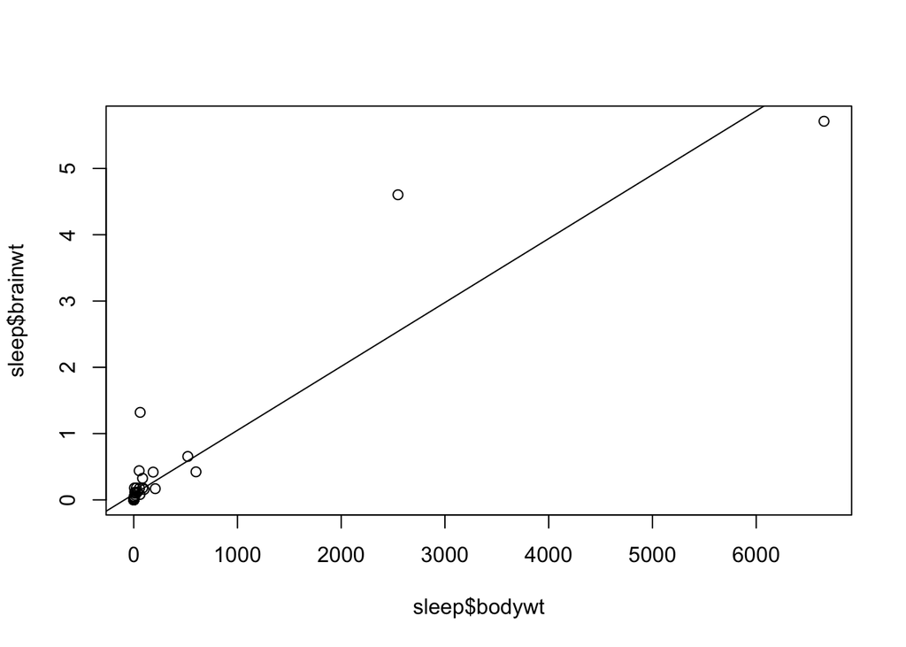

```r
abline(L)
```

```r
# Code below given for residual plot
length(sleep$bodywt)
```

```
## [1] 83
```

```r
length(L$residuals)
```

```
## [1] 56
```

```r
residuals1 = resid(lm(sleep$brainwt ~ sleep$bodywt, na.action=na.exclude))
length(residuals1)
```

```
## [1] 83
```

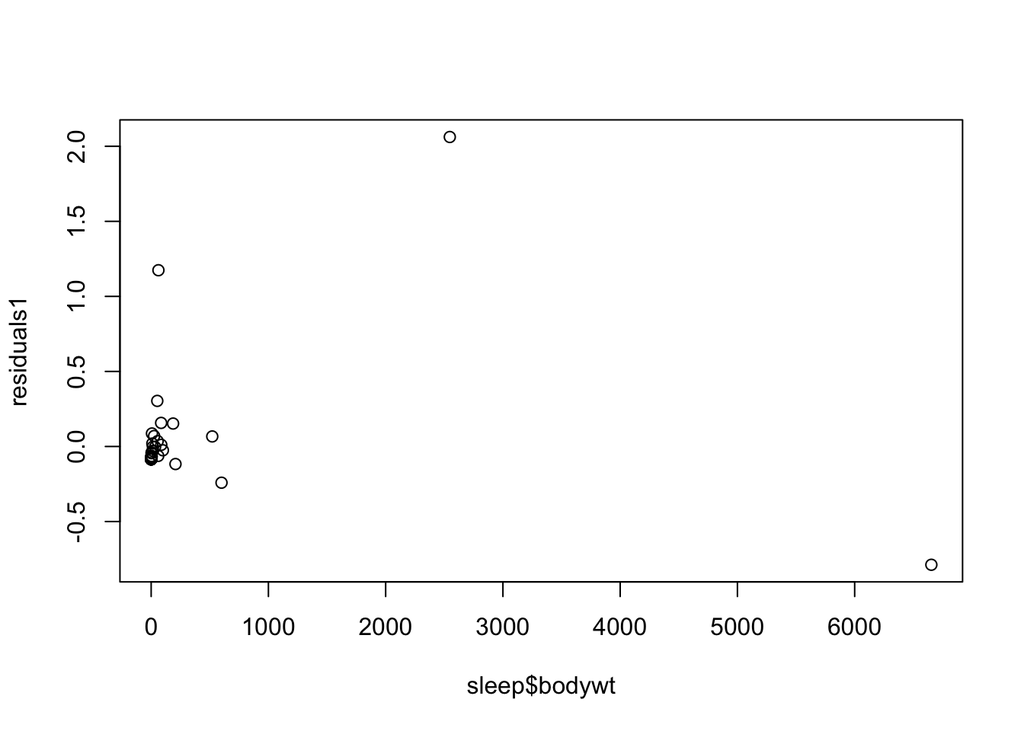

```r
plot(sleep$bodywt,residuals1)
```

## 0.3 CHI-SQUARED TEST

**Research Question**: It is postulated that the proportions of carnivores, herbivores, insectivores and omivores is in the ratio 0.2 : 0.4 : 0.1 : 0.3. Test this claim.

```r
# Put your code here

table(sleep$vore)
```

```
##
##   carni   herbi insecti    omni
##      19      32       5      20
```

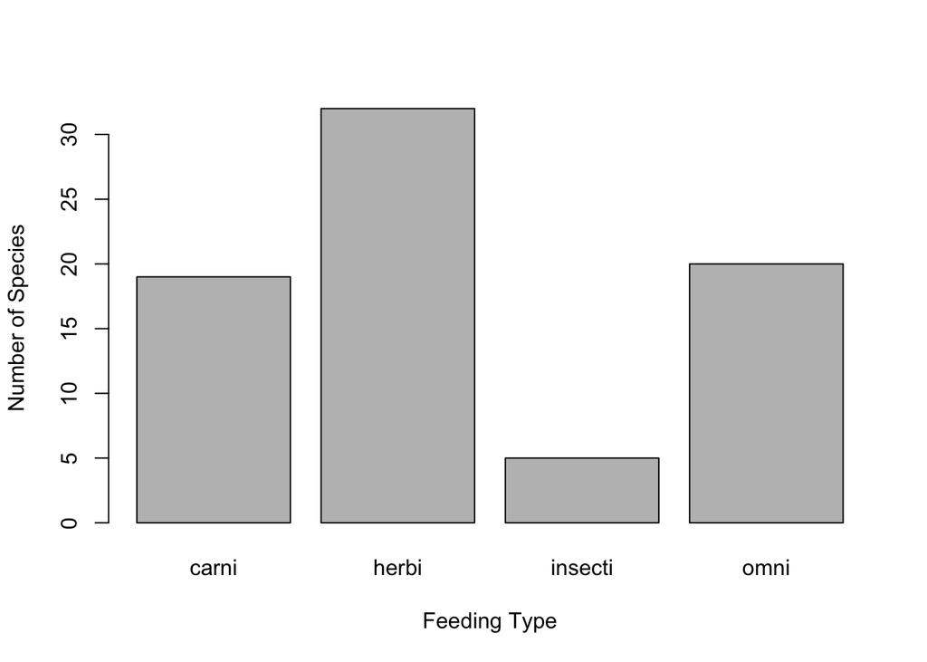

```r
barplot(table(sleep$vore), xlab='Feeding Type', ylab='Number of Species')
```

```r
chisq.test(table(sleep$vore), p = c(0.2, 0.4, 0.1, 0.3))
```

```
##
##  Chi-squared test for given probabilities
##
## data:  table(sleep$vore)
## X-squared = 2.2675, df = 3, p-value = 0.5188
```

The model appears to be a good fit.

## 0.4 BINOMIAL MODELLING

Context: Assume a random sample of 30 mammals is collected. Modelling by a box model, find the expected number of herbivores. What is the chance of observing 15 or more mammals?

```r
# Add Code Here
library(multicon)  # allows us to used popsd()
set.seed(1)
box=c(1,0)
box1 = sample(box, 30, prob = c(0.4, 0.6), rep = T)  # Here we use the poportion from hypothesis test above.
table(box1)
```

```
## box1
##  0  1
## 17 13
```

```r
ev = 30 * mean(box1)
se = sqrt(30)* popsd(box1)
c(ev,se)
```

```
## [1] 13.00000  2.71416
```

```r
# Binomial Model
pbinom(15, 30, 0.4, lower.tail = F)
```

```
## [1] 0.09705684
```

## 0.5 DATA WRANGLING

Annotate the code below, so that it explains what each line is doing.

```r
# code given

ggplot(data=sleep, aes(x=bodywt, y=sleep_total, col = vore))+geom_point() # A scatter plot of total sleep vs body weight, coloured by the trophic (feeding) level.

sleep %>%
  count(order, sort = TRUE)  # counts the orders of the mammals, and then sorts from top to bottom.

sleep %>%
  group_by(vore) %>%
  summarise(n = n(), average = mean(sleep_total)/24)
# Calculates the average proportion of the day slept by each trophic (eating) level.
```